# Microarray Data

#### Microarray technology has become one of the indispensable tools that many biologists use to monitor genome wide expression levels of genes in a given organism. A microarray is typically a glass slide on to which DNA molecules are fi xed in an orderly manner at specific locations called spots (or features). A microarray may contain thousands of spots and each spot may contain a few million copies of identical DNA molecules that uniquely correspond to a gene.The DNA in a spot may either be genomic DNA or short stretch of oligo-nucleotide strands that correspond to a gene. The spots are printed on to the glass slide by a robot or are synthesised by the process of photolithography. Microarrays may be used to measure gene expression in many ways, but one of the most popular applications is to compare expression of a set of genes from a cell maintained in a particular condition (condition A) to the same set of genes from a reference cell maintained under normal conditions (condition B).

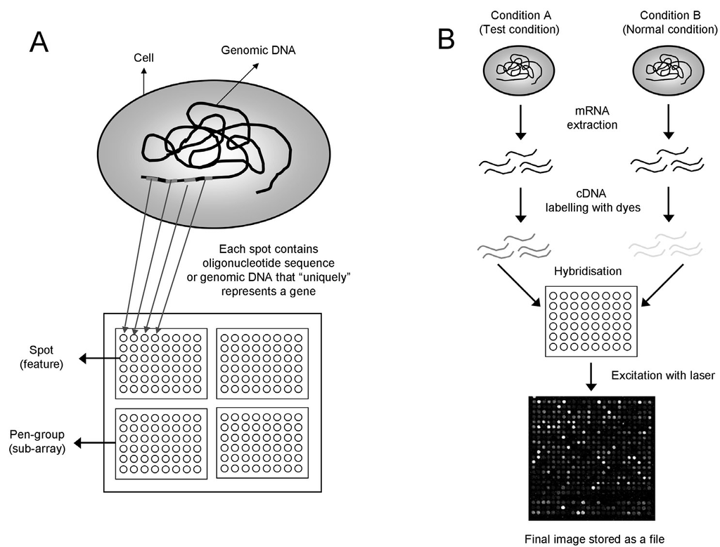

image source - https://www.mrc-lmb.cam.ac.uk/genomes/madanm/microarray/

#### The above figure gives a general picture of the experimental steps involved. First, RNA is extracted from the cells. Next, RNA molecules in the extract are reverse transcribed into cDNA by using an enzyme reverse transcriptase and nucleotides labelled with different fl uorescent dyes. For example, cDNA from cells grown in condition A may be labelled with a red dye and from cells grown in condition B with a green dye. Once the samples have been differentially labelled, they are allowed to hybridize onto the same glass slide. At this point, any cDNA sequence in the sample will hybridize to specifi c spots on the glass slide containing its complementary sequence. The amount of cDNA bound to a spot will be directly proportional to the initial number of RNA molecules present for that gene in both samples.

#### Following the hybridization step, the spots in the hybridized microarray are excited by a laser and scanned at suitable wavelengths to detect the red and green dyes. The amount of fluorescence emitted upon excitation corresponds to the amount of bound nucleic acid. For instance, if cDNA from condition A for a particular gene was in greater abundance than that from condition B, one would fi nd the spot to be red. If it was the other way, the spot would be green. If the gene was expressed to the same extent in both conditions, one would find the spot to be yellow, and if the gene was not expressed in both conditions, the spot would be black. Thus, what is seen at the end of the experimental stage is an image of the microarray, in which each spot that corresponds to a gene has an associated fl uorescence value representing the relative expression level of that gene.

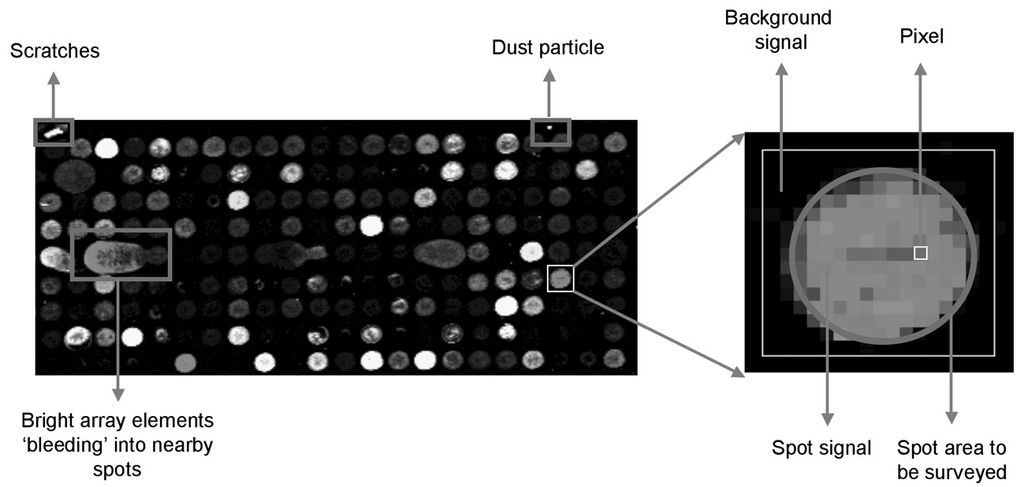

image source - https://www.mrc-lmb.cam.ac.uk/genomes/madanm/microarray/

# Downloading Microarray Data

### Download the microarray dataset from ncbi website. For this excersize we use a small microarray data which has deposited into gene Expression Omnibus Database. This study was performed using two sets of microarrays for each sample. Set "A" contain the main features and sets "B" contain other genes which may be interesting.

### Link - https://www.ncbi.nlm.nih.gov/sites/GDSbrowser?acc=GDS2744

### Using the above link download the ".annot" and "seris_matrix_file" files and store them into working directory.

## Dataset Description:

```
         Title - Dioxin effect on breast cancer cell line
         Organism - Homo sapiens
         Platform - PL96: [HG-U133A] Affymetrix Human Genome U133A Array
         Summary - Analysis of MCF-7 breast cancer cells treated with 100 nM dioxin. Although dioxin is causative for many types of cancers, low exposure to dioxin is associated with a decreased incidence of breast carcinoma. Results provide insight into the molecular basis of this protective effect.
```

# Installing required Library

## Bioconductor:

```
                    Bioconductor provides tools for the analysis and comprehension of high-throughput genomic data. Bioconductor uses the R statistical programming language, and is open source and open development. It has two releases each year, and an active user community.
```

## golubEsets:

```
        Representation of public golub data with some covariate data of provenance unknown to the maintainer at present; now employs ExpressionSet format
```

## affy:

```
       The package contains functions for exploratory oligonucleotide array analysis. The dependence on tkWidgets only concerns few convenience functions. 'affy' is fully functional without it.
```

## GEOquery:

```
            The NCBI Gene Expression Omnibus (GEO) is a public repository of microarray data. Given the rich and varied nature of this resource, it is only natural to want to apply BioConductor tools to these data. GEOquery is the bridge between GEO and BioConductor.
```

# Installing Bioconductor

```r
if (!requireNamespace("BiocManager", quietly = TRUE))
    install.packages("BiocManager")
BiocManager::install()
```

# Check for the packages that are available or not

```r
BiocManager::available("golubEsets")
BiocManager::available("GEOquery")
BiocManager::available("affy")
```

# Install the following packages:

```
  Note -  At the time of installing some dependencies has to be installed like - 'limma' packages, which is very usefull for further analysis
```

```r
BiocManager::install("golubEsets")
BiocManager::install("GEOquery")
BiocManager::install("affy")
```

# Loading data to the Environment

## Set working directory

```r
datadir <- "D:/R Notebook/"
```

## Read the info of series matrix file

```r
info <- readLines(file.path(datadir, "GSE7765-GPL96_series_matrix.txt"), n=70)
```

```r
info
```

1. '!Series_title\t"Dioxin-induced gene expression changes in MCF-7 human breast cancer cells"'

2. '!Series_geo_accession\t"GSE7765"'

3. '!Series_status\t"Public on May 12 2007"'

4. '!Series_submission_date\t"May 09 2007"'

5. '!Series_last_update_date\t"Aug 29 2013"'

6. '!Series_pubmed_id\t"17517823"'

7. '!Series_summary\t"MCF7 cells were treated with DMSO or 100 nM Dioxin for 16 hr. Gene expression changes were quantified by microarray analyses."'

8. '!Series_summary\t"Keywords: dose response"'

9. '!Series_overall_design\t"HU133A and B arrays were used to quantify differences in RNA after treatment with 100 nM dioxin for 16 h. The experiment was repeated 3 times."'

10. '!Series_type\t"Expression profiling by array"'

11. '!Series_contributor\t"Diana,,Yoon"'

12. '!Series_contributor\t"Oliver,,Hankinson"'

13. '!Series_sample_id\t"GSM188012 GSM188013 GSM188014 GSM188015 GSM188016 GSM188017 GSM188018 GSM188019 GSM188020 GSM188021 GSM188022 GSM188023 "'

14. '!Series_contact_name\t"Oliver ,,Hankinson"'

15. '!Series_contact_email\t"ohank@mednet.ucla.edu"'

16. '!Series_contact_phone\t"(310) 825-2936"'

17. '!Series_contact_fax\t"(310) 794-9272"'

18. '!Series_contact_laboratory\t"CHS-Hankinson"'

19. '!Series_contact_department\t"Pathology and Laboratory Medicine"'

20. '!Series_contact_institute\t"UCLA"'

21. '!Series_contact_address\t"PO Box 951732"'

22. '!Series_contact_city\t"Los Angeles"'

23. '!Series_contact_state\t"CA"'

24. '!Series_contact_zip/postal_code\t"90095-1732"'

25. '!Series_contact_country\t"USA"'

26. '!Series_supplementary_file\t"ftp://ftp.ncbi.nlm.nih.gov/pub/geo/DATA/supplementary/series/GSE7765/GSE7765_RAW.tar"'

27. '!Series_platform_id\t"GPL96"'

28. '!Series_platform_id\t"GPL97"'

29. '!Series_platform_taxid\t"9606"'

30. '!Series_sample_taxid\t"9606"'

31. '!Series_relation\t"BioProject: http://www.ncbi.nlm.nih.gov/bioproject/PRJNA99779"'

32. ''

33. '!Sample_title\t"DMSO treated MCF7 breast cancer cells [HG-U133A] Exp 1"\t"Dioxin treated MCF7 breast cancer cells [HG-U133A] Exp 1"\t"DMSO treated MCF7 breast cancer cells [HG-U133A] Exp 2"\t"Dioxin treated MCF7 breast cancer cells [HG-U133A] Exp 2"\t"DMSO treated MCF7 breast cancer cells [HG-U133A] Exp 3"\t"Dioxin treated MCF7 breast cancer cells [HG-U133A] Exp 3"'

34. '!Sample_geo_accession\t"GSM188013"\t"GSM188014"\t"GSM188016"\t"GSM188018"\t"GSM188020"\t"GSM188022"'

35. '!Sample_status\t"Public on May 12 2007"\t"Public on May 12 2007"\t"Public on May 12 2007"\t"Public on May 12 2007"\t"Public on May 12 2007"\t"Public on May 12 2007"'

36. '!Sample_submission_date\t"May 08 2007"\t"May 08 2007"\t"May 08 2007"\t"May 08 2007"\t"May 08 2007"\t"May 08 2007"'

37. '!Sample_last_update_date\t"May 11 2007"\t"May 11 2007"\t"May 11 2007"\t"May 11 2007"\t"May 11 2007"\t"May 11 2007"'

38. '!Sample_type\t"RNA"\t"RNA"\t"RNA"\t"RNA"\t"RNA"\t"RNA"'

39. '!Sample_channel_count\t"1"\t"1"\t"1"\t"1"\t"1"\t"1"'

40. '!Sample_source_name_ch1\t"MCF7 human breast cancer cells, DMSO-treated"\t"MCF7 human breast cancer cells, dioxin-treated"\t"MCF7 human breast cancer cells, DMSO-treated"\t"MCF7 human breast cancer cells, dioxin-treated"\t"MCF7 human breast cancer cells, DMSO-treated"\t"MCF7 human breast cancer cells, dioxin-treated"'

41. '!Sample_organism_ch1\t"Homo sapiens"\t"Homo sapiens"\t"Homo sapiens"\t"Homo sapiens"\t"Homo sapiens"\t"Homo sapiens"'

42. '!Sample_characteristics_ch1\t"16 hr DMSO treatment"\t"16 hr dioxin treatment"\t"16 hr DMSO treatment"\t"16 hr dioxin treatment"\t"16 hr DMSO treatment"\t"16 hr dioxin treatment"'

43. '!Sample_molecule_ch1\t"total RNA"\t"total RNA"\t"total RNA"\t"total RNA"\t"total RNA"\t"total RNA"'

44. '!Sample_extract_protocol_ch1\t"Qiagen RNeasy kit"\t"Qiagen RNeasy kit"\t"Qiagen RNeasy kit"\t"Qiagen RNeasy kit"\t"Qiagen RNeasy kit"\t"Qiagen RNeasy kit"'

45. '!Sample_label_ch1\t"biotin"\t"biotin"\t"biotin"\t"biotin"\t"biotin"\t"biotin"'

46. '!Sample_label_protocol_ch1\t"Enzo Biotin labeling"\t"Enzo Biotin labeling"\t"Enzo Biotin labeling"\t"Enzo Biotin labeling"\t"Enzo Biotin labeling"\t"Enzo Biotin labeling"'

47. '!Sample_taxid_ch1\t"9606"\t"9606"\t"9606"\t"9606"\t"9606"\t"9606"'

48. '!Sample_hyb_protocol\t"15ug of CRNA was fragmented, fragmented product was checked on gel(average size 100nt), Hybridization cocktail added and hybed on HG_U133A arrays. Washed with non-stringent wash buffer (A) and stained with SAPE solution."\t"15ug of CRNA was fragmented, fragmented product was checked on gel(average size 100nt), Hybridization cocktail added and hybed on HG_U133A arrays. Washed with non-stringent wash buffer (A) and stained with SAPE solution."\t"15ug of CRNA was fragmented, fragmented product was checked on gel(average size 100nt), Hybridization cocktail added and hybed on HG_U133A arrays. Washed with non-stringent wash buffer (A) and stained with SAPE solution."\t"15ug of CRNA was fragmented, fragmented product was checked on gel(average size 100nt), Hybridization cocktail added and hybed on HG_U133A arrays. Washed with non-stringent wash buffer (A) and stained with SAPE solution."\t"15ug of CRNA was fragmented, fragmented product was checked on gel(average size 100nt), Hybridization cocktail added and hybed on HG_U133A arrays. Washed with non-stringent wash buffer (A) and stained with SAPE solution."\t"15ug of CRNA was fragmented, fragmented product was checked on gel(average size 100nt), Hybridization cocktail added and hybed on HG_U133A arrays. Washed with non-stringent wash buffer (A) and stained with SAPE solution."'

49. '!Sample_scan_protocol\t"HP Genechip Scanner (fixed pixel and wavelength)"\t"HP Genechip Scanner (fixed pixel and wavelength)"\t"HP Genechip Scanner (fixed pixel and wavelength)"\t"HP Genechip Scanner (fixed pixel and wavelength)"\t"HP Genechip Scanner (fixed pixel and wavelength)"\t"HP Genechip Scanner (fixed pixel and wavelength)"'

50. '!Sample_description\t"MCF7 human breast cancer cells treated with DMSO and used as a control in a 2 platform, three replicate experiment"\t"MCF7 human breast cancer cells treated with 100 nM of dioxin to quantify RNA differences in a 2 platform, three replicate experiment"\t"MCF7 human breast cancer cells treated with DMSO and used as a control in a 2 platform, three replicate experiment"\t"MCF7 human breast cancer cells treated with 100 nM of dioxin to quantify RNA differences in a 2 platform, three replicate experiment"\t"MCF7 human breast cancer cells treated with DMSO and used as a control in a 2 platform, three replicate experiment"\t"MCF7 human breast cancer cells treated with 100 nM of dioxin to quantify RNA differences in a 2 platform, three replicate experiment"'

51. '!Sample_data_processing\t"Probe array type- HG_U133 A. Parameters - defaults. Normalization - all probe sets. Scaling - all probe sets (Target signal - 2500)"\t"Probe array type- HG_U133 A. Parameters - defaults. Normalization - all probe sets. Scaling - all probe sets (Target signal - 2500)"\t"Probe array type- HG_U133 A. Parameters - defaults. Normalization - all probe sets. Scaling - all probe sets (Target signal - 2500)"\t"Probe array type- HG_U133 A. Parameters - defaults. Normalization - all probe sets. Scaling - all probe sets (Target signal - 2500)"\t"Probe array type- HG_U133 A. Parameters - defaults. Normalization - all probe sets. Scaling - all probe sets (Target signal - 2500)"\t"Probe array type- HG_U133 A. Parameters - defaults. Normalization - all probe sets. Scaling - all probe sets (Target signal - 2500)"'

52. '!Sample_platform_id\t"GPL96"\t"GPL96"\t"GPL96"\t"GPL96"\t"GPL96"\t"GPL96"'

53. '!Sample_contact_name\t"Oliver ,,Hankinson"\t"Oliver ,,Hankinson"\t"Oliver ,,Hankinson"\t"Oliver ,,Hankinson"\t"Oliver ,,Hankinson"\t"Oliver ,,Hankinson"'

54. '!Sample_contact_email\t"ohank@mednet.ucla.edu"\t"ohank@mednet.ucla.edu"\t"ohank@mednet.ucla.edu"\t"ohank@mednet.ucla.edu"\t"ohank@mednet.ucla.edu"\t"ohank@mednet.ucla.edu"'

55. '!Sample_contact_phone\t"(310) 825-2936"\t"(310) 825-2936"\t"(310) 825-2936"\t"(310) 825-2936"\t"(310) 825-2936"\t"(310) 825-2936"'

56. '!Sample_contact_fax\t"(310) 794-9272"\t"(310) 794-9272"\t"(310) 794-9272"\t"(310) 794-9272"\t"(310) 794-9272"\t"(310) 794-9272"'

57. '!Sample_contact_laboratory\t"CHS-Hankinson"\t"CHS-Hankinson"\t"CHS-Hankinson"\t"CHS-Hankinson"\t"CHS-Hankinson"\t"CHS-Hankinson"'

58. '!Sample_contact_department\t"Pathology and Laboratory Medicine"\t"Pathology and Laboratory Medicine"\t"Pathology and Laboratory Medicine"\t"Pathology and Laboratory Medicine"\t"Pathology and Laboratory Medicine"\t"Pathology and Laboratory Medicine"'

59. '!Sample_contact_institute\t"UCLA"\t"UCLA"\t"UCLA"\t"UCLA"\t"UCLA"\t"UCLA"'

60. '!Sample_contact_address\t"PO Box 951732"\t"PO Box 951732"\t"PO Box 951732"\t"PO Box 951732"\t"PO Box 951732"\t"PO Box 951732"'

61. '!Sample_contact_city\t"Los Angeles"\t"Los Angeles"\t"Los Angeles"\t"Los Angeles"\t"Los Angeles"\t"Los Angeles"'

62. '!Sample_contact_state\t"CA"\t"CA"\t"CA"\t"CA"\t"CA"\t"CA"'

63. '!Sample_contact_zip/postal_code\t"90095-1732"\t"90095-1732"\t"90095-1732"\t"90095-1732"\t"90095-1732"\t"90095-1732"'

64. '!Sample_contact_country\t"USA"\t"USA"\t"USA"\t"USA"\t"USA"\t"USA"'

65. '!Sample_supplementary_file\t"ftp://ftp.ncbi.nlm.nih.gov/pub/geo/DATA/supplementary/samples/GSM188nnn/GSM188013/GSM188013.CEL.gz"\t"ftp://ftp.ncbi.nlm.nih.gov/pub/geo/DATA/supplementary/samples/GSM188nnn/GSM188014/GSM188014.CEL.gz"\t"ftp://ftp.ncbi.nlm.nih.gov/pub/geo/DATA/supplementary/samples/GSM188nnn/GSM188016/GSM188016.CEL.gz"\t"ftp://ftp.ncbi.nlm.nih.gov/pub/geo/DATA/supplementary/samples/GSM188nnn/GSM188018/GSM188018.CEL.gz"\t"ftp://ftp.ncbi.nlm.nih.gov/pub/geo/DATA/supplementary/samples/GSM188nnn/GSM188020/GSM188020.CEL.gz"\t"ftp://ftp.ncbi.nlm.nih.gov/pub/geo/DATA/supplementary/samples/GSM188nnn/GSM188022/GSM188022.CEL.gz"'

66. '!Sample_supplementary_file\t"ftp://ftp.ncbi.nlm.nih.gov/pub/geo/DATA/supplementary/samples/GSM188nnn/GSM188013/GSM188013.CHP.gz"\t"ftp://ftp.ncbi.nlm.nih.gov/pub/geo/DATA/supplementary/samples/GSM188nnn/GSM188014/GSM188014.CHP.gz"\t"ftp://ftp.ncbi.nlm.nih.gov/pub/geo/DATA/supplementary/samples/GSM188nnn/GSM188016/GSM188016.CHP.gz"\t"ftp://ftp.ncbi.nlm.nih.gov/pub/geo/DATA/supplementary/samples/GSM188nnn/GSM188018/GSM188018.CHP.gz"\t"ftp://ftp.ncbi.nlm.nih.gov/pub/geo/DATA/supplementary/samples/GSM188nnn/GSM188020/GSM188020.CHP.gz"\t"ftp://ftp.ncbi.nlm.nih.gov/pub/geo/DATA/supplementary/samples/GSM188nnn/GSM188022/GSM188022.CHP.gz"'

67. '!Sample_supplementary_file\t"ftp://ftp.ncbi.nlm.nih.gov/pub/geo/DATA/supplementary/samples/GSM188nnn/GSM188013/GSM188013.EXP.gz"\t"ftp://ftp.ncbi.nlm.nih.gov/pub/geo/DATA/supplementary/samples/GSM188nnn/GSM188014/GSM188014.EXP.gz"\t"ftp://ftp.ncbi.nlm.nih.gov/pub/geo/DATA/supplementary/samples/GSM188nnn/GSM188016/GSM188016.EXP.gz"\t"ftp://ftp.ncbi.nlm.nih.gov/pub/geo/DATA/supplementary/samples/GSM188nnn/GSM188018/GSM188018.EXP.gz"\t"ftp://ftp.ncbi.nlm.nih.gov/pub/geo/DATA/supplementary/samples/GSM188nnn/GSM188020/GSM188020.EXP.gz"\t"ftp://ftp.ncbi.nlm.nih.gov/pub/geo/DATA/supplementary/samples/GSM188nnn/GSM188022/GSM188022.EXP.gz"'

68. '!Sample_data_row_count\t"22283"\t"22283"\t"22283"\t"22283"\t"22283"\t"22283"'

69. '!series_matrix_table_begin'

70. '"ID_REF"\t"GSM188013"\t"GSM188014"\t"GSM188016"\t"GSM188018"\t"GSM188020"\t"GSM188022"'

## Load the series matrix File

```r
x <- read.table(file.path("GSE7765-GPL96_series_matrix.txt"), skip = 69, header = TRUE, sep ="\t", row.names = 1,fill = TRUE)
```

## Look at the data what just created from the series matrix file and stored in a table named x

```r
dim(x)
names(x)
```

1. 22284

2. 6

1. 'GSM188013'

2. 'GSM188014'

3. 'GSM188016'

4. 'GSM188018'

5. 'GSM188020'

6. 'GSM188022'

## Load the gpl .annot file

```r
library("GEOquery")
gpl96 <- getGEO(filename = 'GPL96.annot')
```

## View the column name available in the dataset(.annot file)

```r
Meta(gpl96)$title
colnames(Table(gpl96))
```

1. 'ID'

2. 'Gene title'

3. 'Gene symbol'

4. 'Gene ID'

5. 'UniGene title'

6. 'UniGene symbol'

7. 'UniGene ID'

8. 'Nucleotide Title'

9. 'GI'

10. 'GenBank Accession'

11. 'Platform_CLONEID'

12. 'Platform_ORF'

13. 'Platform_SPOTID'

14. 'Chromosome location'

15. 'Chromosome annotation'

16. 'GO:Function'

17. 'GO:Process'

18. 'GO:Component'

19. 'GO:Function ID'

20. 'GO:Process ID'

21. 'GO:Component ID'

## Remove useless columns and sort the working table data

```r
Table(gpl96)[1:10,1:4]
```

A data.frame: 10 × 4

|  | ID <chr> | Gene title <chr> | Gene symbol <chr> | Gene ID <chr> |
| --- | --- | --- | --- | --- |
| 1 | 1007_s_at | discoidin domain receptor tyrosine kinase 1 | DDR1 | 780 |
| 2 | 1053_at | replication factor C (activator 1) 2, 40kDa | RFC2 | 5982 |
| 3 | 117_at | heat shock 70kDa protein 6 (HSP70B') | HSPA6 | 3310 |
| 4 | 121_at | paired box 8 | PAX8 | 7849 |
| 5 | 1255_g_at | guanylate cyclase activator 1A (retina) | GUCA1A | 2978 |
| 6 | 1294_at | ubiquitin-like modifier activating enzyme 7 | UBA7 | 7318 |
| 7 | 1316_at | thyroid hormone receptor, alpha | THRA | 7067 |
| 8 | 1320_at | protein tyrosine phosphatase, non-receptor type 21 | PTPN21 | 11099 |
| 9 | 1405_i_at | chemokine (C-C motif) ligand 5 | CCL5 | 6352 |
| 10 | 1431_at | cytochrome P450, family 2, subfamily E, polypeptide 1 | CYP2E1 | 1571 |

```r
Table(gpl96)[1:10,c("ID","Gene title")]
```

A data.frame: 10 × 2

|  | ID <chr> | Gene title <chr> |
| --- | --- | --- |
| 1 | 1007_s_at | discoidin domain receptor tyrosine kinase 1 |
| 2 | 1053_at | replication factor C (activator 1) 2, 40kDa |
| 3 | 117_at | heat shock 70kDa protein 6 (HSP70B') |
| 4 | 121_at | paired box 8 |
| 5 | 1255_g_at | guanylate cyclase activator 1A (retina) |
| 6 | 1294_at | ubiquitin-like modifier activating enzyme 7 |
| 7 | 1316_at | thyroid hormone receptor, alpha |
| 8 | 1320_at | protein tyrosine phosphatase, non-receptor type 21 |
| 9 | 1405_i_at | chemokine (C-C motif) ligand 5 |
| 10 | 1431_at | cytochrome P450, family 2, subfamily E, polypeptide 1 |

```r
Table(gpl96)[1:10,c("ID","Gene title","Gene symbol","Gene ID","GenBank Accession")]
```

A data.frame: 10 × 5

|  | ID <chr> | Gene title <chr> | Gene symbol <chr> | Gene ID <chr> | GenBank Accession <chr> |
| --- | --- | --- | --- | --- | --- |
| 1 | 1007_s_at | discoidin domain receptor tyrosine kinase 1 | DDR1 | 780 | U48705 |
| 2 | 1053_at | replication factor C (activator 1) 2, 40kDa | RFC2 | 5982 | M87338 |
| 3 | 117_at | heat shock 70kDa protein 6 (HSP70B') | HSPA6 | 3310 | X51757 |
| 4 | 121_at | paired box 8 | PAX8 | 7849 | X69699 |
| 5 | 1255_g_at | guanylate cyclase activator 1A (retina) | GUCA1A | 2978 | L36861 |
| 6 | 1294_at | ubiquitin-like modifier activating enzyme 7 | UBA7 | 7318 | L13852 |
| 7 | 1316_at | thyroid hormone receptor, alpha | THRA | 7067 | X55005 |
| 8 | 1320_at | protein tyrosine phosphatase, non-receptor type 21 | PTPN21 | 11099 | X79510 |
| 9 | 1405_i_at | chemokine (C-C motif) ligand 5 | CCL5 | 6352 | M21121 |
| 10 | 1431_at | cytochrome P450, family 2, subfamily E, polypeptide 1 | CYP2E1 | 1571 | J02843 |

## Create a table for Gene ID and Gene Symbol

```r
ID <- attr(dataTable(gpl96), "table")[,c("ID", "Gene symbol")]
head(ID)
```

A data.frame: 6 × 2

|  | ID <chr> | Gene symbol <chr> |
| --- | --- | --- |
| 1 | 1007_s_at | DDR1 |
| 2 | 1053_at | RFC2 |
| 3 | 117_at | HSPA6 |
| 4 | 121_at | PAX8 |
| 5 | 1255_g_at | GUCA1A |
| 6 | 1294_at | UBA7 |

## Now Check the series matrix file and remove the last line from the matrix

```r
x <-x[-22284,]
dim(x)
names(x)
round(apply(x, 2, summary))
#head(x)
```

1. 22283

2. 6

1. 'GSM188013'

2. 'GSM188014'

3. 'GSM188016'

4. 'GSM188018'

5. 'GSM188020'

6. 'GSM188022'

A matrix: 6 × 6 of type dbl

|  | GSM188013 | GSM188014 | GSM188016 | GSM188018 | GSM188020 | GSM188022 |
| --- | --- | --- | --- | --- | --- | --- |
| Min. | 1 | 1 | 2 | 2 | 1 | 1 |
| 1st Qu. | 327 | 317 | 192 | 233 | 172 | 169 |
| Median | 1146 | 1102 | 774 | 844 | 692 | 686 |
| Mean | 3459 | 3451 | 3364 | 3503 | 3438 | 3536 |
| 3rd Qu. | 3052 | 3055 | 2968 | 2880 | 2853 | 2860 |
| Max. | 115359 | 112557 | 95911 | 115259 | 104002 | 119307 |

## Replace row name with the corresponding gene symbol

```r
x <- as.matrix(x)
rows <-rownames(x)
rows[3200]
which(ID[,1] == rows[3200])
ID[which(ID[,1] == rows[3200]), 2]
symb <- rep(0, length(rows))
for (i in 1:length(rows)) {
  symb[i] <- as.character(ID[which(ID[,1] == rows[i]), 2])
}
rownames(x) <- symb
rownames(x)[500]
logX <- log2(x)
round(apply(x, 2, summary), 3)
round(apply(logX, 2, summary), 2)
```

'203673_at'

3200

'TG'

'TSPAN3'

A matrix: 6 × 6 of type dbl

|  | GSM188013 | GSM188014 | GSM188016 | GSM188018 | GSM188020 | GSM188022 |
| --- | --- | --- | --- | --- | --- | --- |
| Min. | 0.735 | 0.887 | 2.009 | 2.452 | 0.547 | 0.806 |
| 1st Qu. | 326.642 | 317.262 | 191.843 | 232.832 | 172.288 | 169.443 |
| Median | 1146.480 | 1102.260 | 773.857 | 844.457 | 691.705 | 686.120 |
| Mean | 3459.432 | 3450.821 | 3363.606 | 3503.050 | 3438.423 | 3535.905 |
| 3rd Qu. | 3052.115 | 3054.720 | 2968.005 | 2879.975 | 2853.225 | 2859.780 |
| Max. | 115359.000 | 112557.000 | 95910.600 | 115259.000 | 104002.000 | 119307.000 |

A matrix: 6 × 6 of type dbl

|  | GSM188013 | GSM188014 | GSM188016 | GSM188018 | GSM188020 | GSM188022 |
| --- | --- | --- | --- | --- | --- | --- |
| Min. | -0.44 | -0.17 | 1.01 | 1.29 | -0.87 | -0.31 |
| 1st Qu. | 8.35 | 8.31 | 7.58 | 7.86 | 7.43 | 7.40 |
| Median | 10.16 | 10.11 | 9.60 | 9.72 | 9.43 | 9.42 |
| Mean | 9.99 | 9.96 | 9.52 | 9.68 | 9.42 | 9.40 |
| 3rd Qu. | 11.58 | 11.58 | 11.54 | 11.49 | 11.48 | 11.48 |
| Max. | 16.82 | 16.78 | 16.55 | 16.81 | 16.67 | 16.86 |

# Data Visualization

## Histogram Plots

### Freequency of x in Histogram

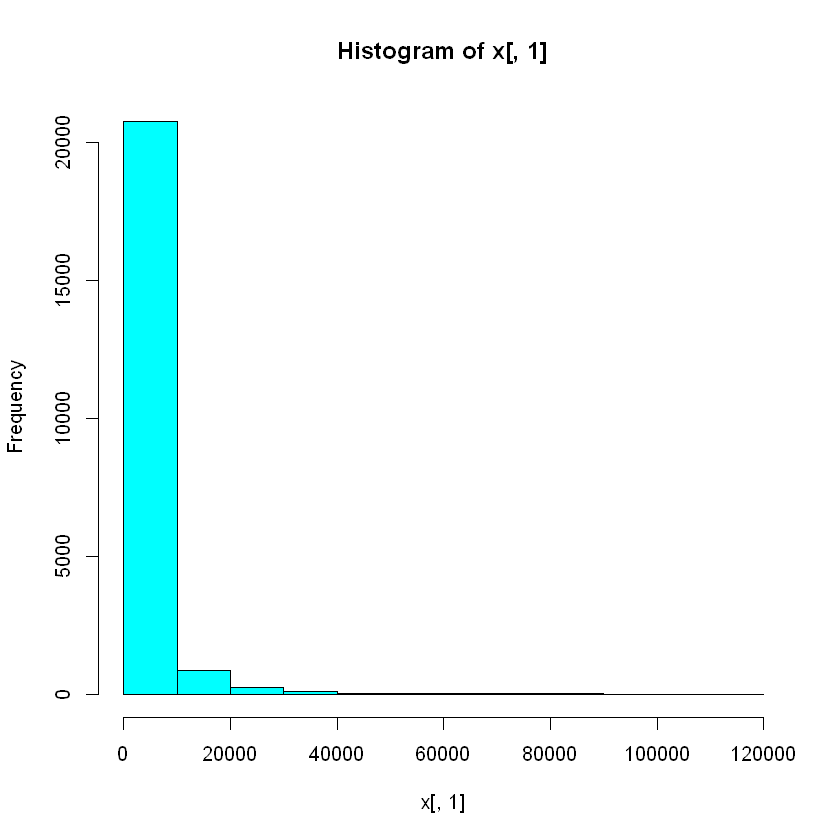

```r
hist(x[,1], col=5)
```

### Freequency of M.1 <-logX[,1] in Histogram plot

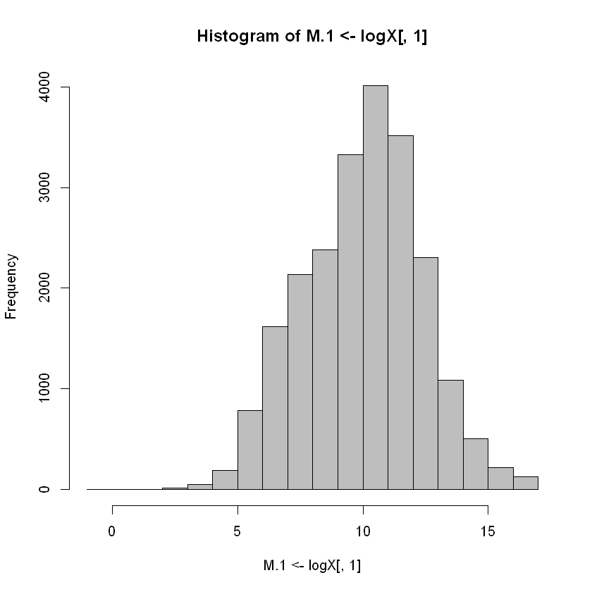

```r
hist(M.1 <-logX[,1],col=8)
```

### Histogram plot of Expression of genes @ no of spots

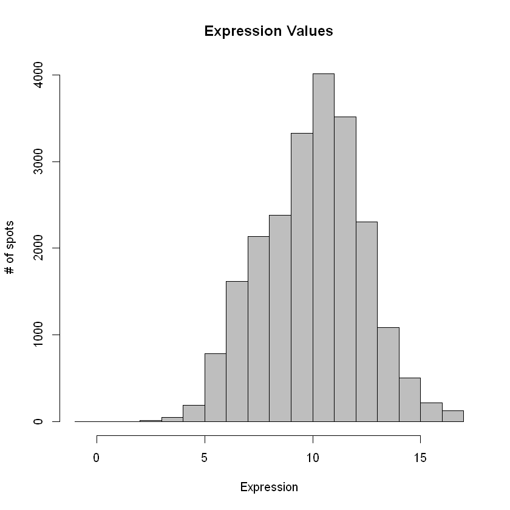

```r
hist(M.1, main="Expression Values", xlab = "Expression", ylab = "# of spots",col = 8)
```

## MA Plot:

[output not shown]

### X1 vs Y1 plot

```r
png(file="X1 vs Y1.png", height = 1080, width = 1440)
opt <-par(mfcol = c(2,1))
plot(X1<-x[,1], Y1<-x[,4])
abline(0,1, col="red")
d <-data.frame(X1, Y1)
dev.off()
```

**png:** 2

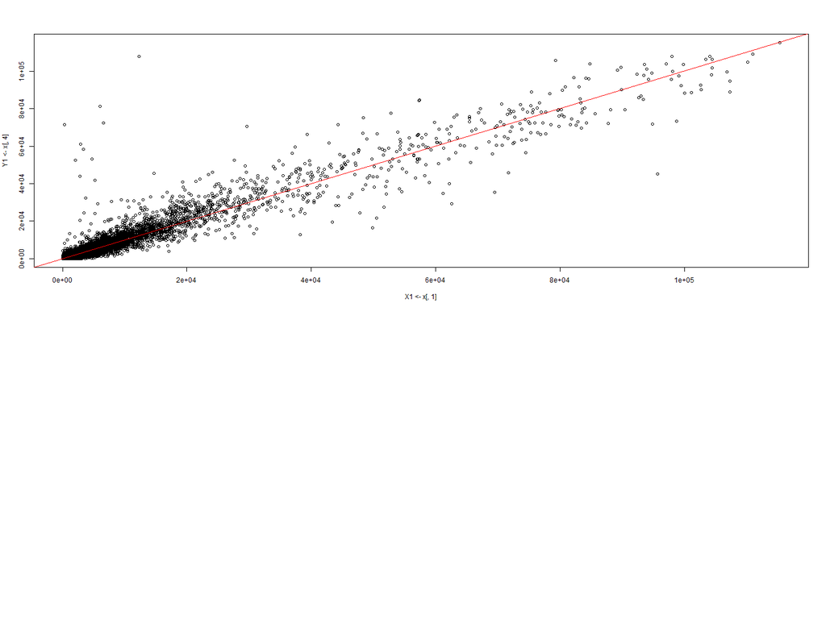

### MA Plot

```r
png(file="MA Plot.png", height = 1080, width = 1080)
M.1<-log2(X1)-log2(Y1)
A.1 <- (log2(X1)+log2(Y1))*0.5
plot(A,M,col=densCols(A.1, M.1), pch=20, cex=0.5)
abline (h=0,col="yellow")
dev.off()
```

**png:** 2

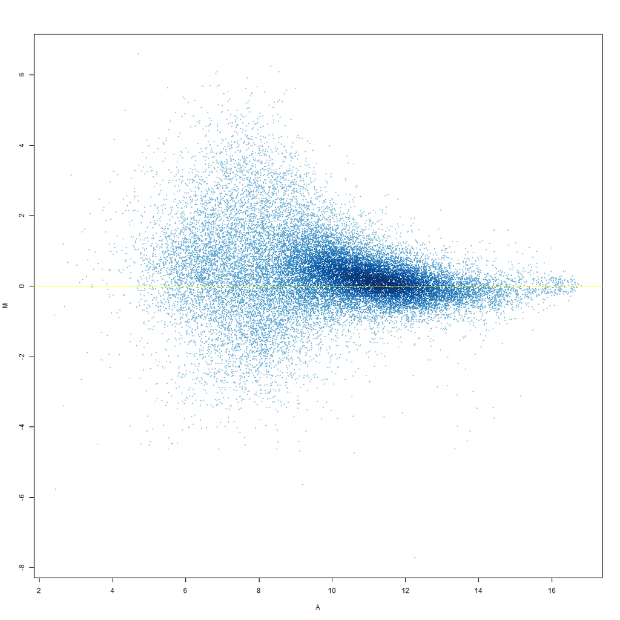

### MA Plot using ma.plot function from affy package

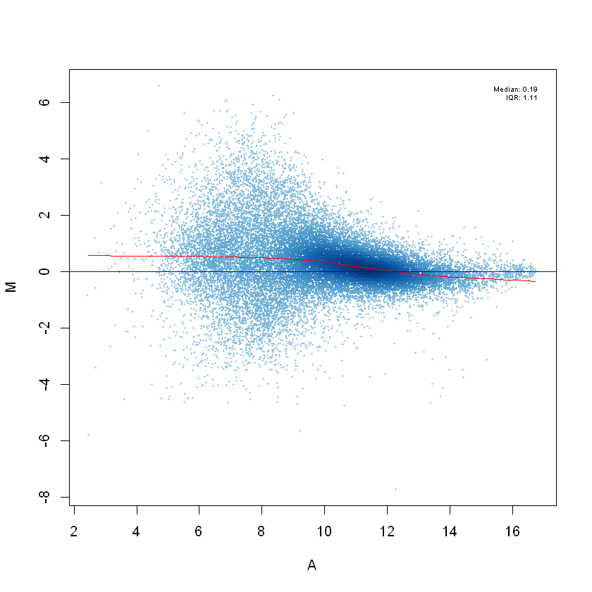

```r
library("affy")
ma.plot(rowMeans(log2(d)), log2(X1)-log2(Y1), cex=0.5,pch=20, col=densCols(A.1, M.1))
```

## Boxplot

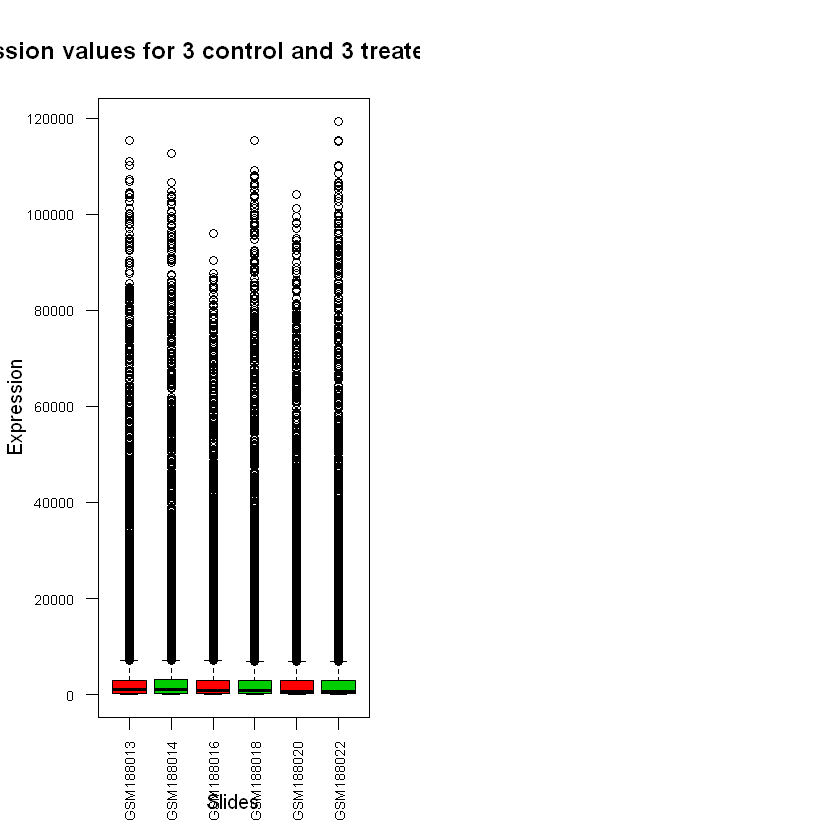

```r
opt <- par(mfcol=c(1,2))
boxplot(x, col=c(2,3,2,3,2,3),main="Expression values for 3 control and 3 treated patients",
        xlab="Slides",ylab="Expression",
        las=2, cex.axis=0.7)
```

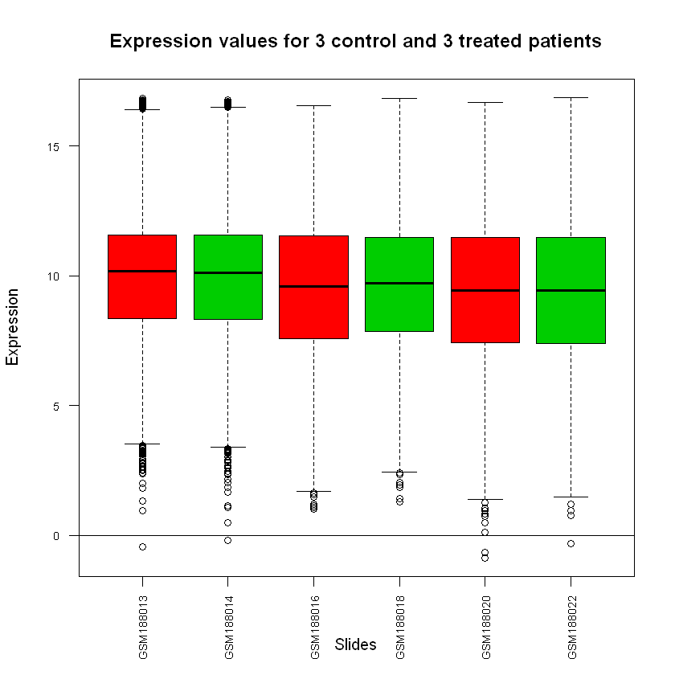

```r
boxplot(logX, col=c(2,3,2,3,2,3), main="Expression values for 3 control and 3 treated patients",
        xlab="Slides",
        ylab="Expression", las=2, cex.axis=0.7)
abline(0,0, col="black")
par(opt)
```

```r
logX.cl<-c(0,1,0,1,0,1)
```

### Define Function to perform t-test

```r
ttest=function(x)
{
  tt=t.test(x[logX.cl==0],x[logX.cl==1])
  return(c(tt$statistic,tt$p.value))
}
```

### Peroform t-test of transformed data

```r
ans=apply(logX,1,ttest)
ts<- ans[1,]
pvals<- ans[2,]
```

### Check for Normality in the resultant data

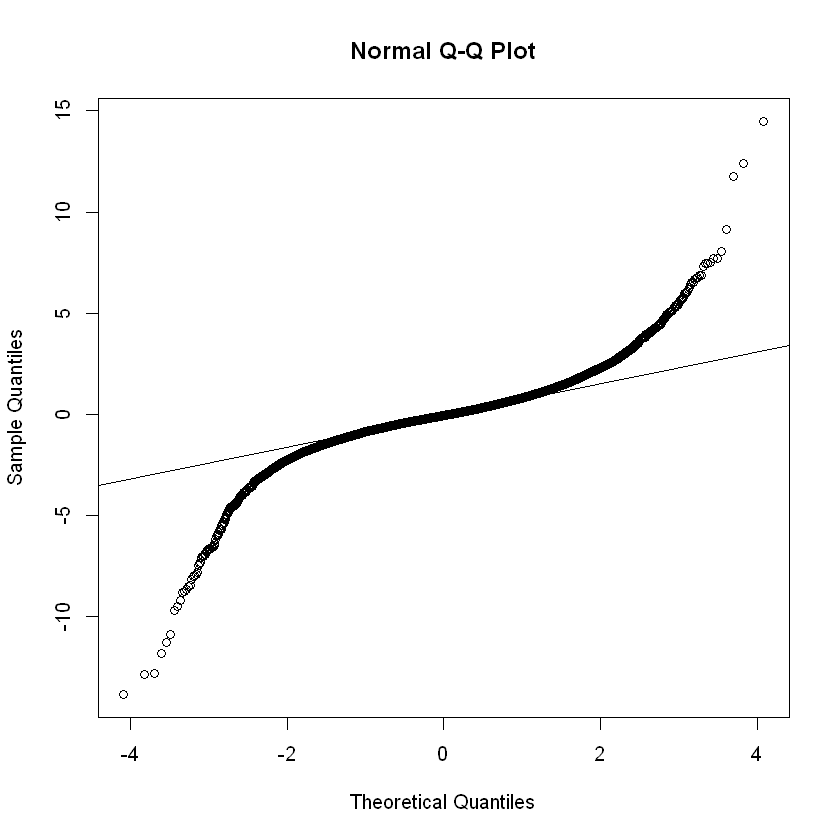

```r
qqnorm(ts)
qqline(ts)
```

## Check how many genes has p-value

```
            Here some of the p-values are given like(0.01,0.05,0.001, 0.0001, 0.00001, 0.000001, 0.0000001) to find out, which gene passes the p-value
```

```r
for (i in c(0.01,0.05,0.001, 0.0001, 0.00001, 0.000001, 0.0000001))
  print(paste("genes with p-values smaller than", i, length(which(pvals < i))))
```

```
[1] "genes with p-values smaller than 0.01 82"
[1] "genes with p-values smaller than 0.05 424"
[1] "genes with p-values smaller than 0.001 7"
[1] "genes with p-values smaller than 1e-04 0"
[1] "genes with p-values smaller than 1e-05 0"
[1] "genes with p-values smaller than 1e-06 0"
[1] "genes with p-values smaller than 1e-07 0"
```

## Now Plotting the heatmap of differentially expressed genes:

[output not shown]

```r
install.packages("pheatmap")
```

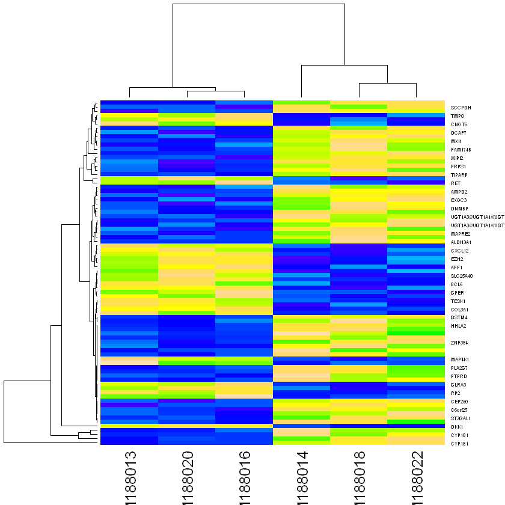

```r
library("pheatmap")
a<-data.frame(which(pvals<0.01))
d<-a[,1]
data<-as.matrix(x=x[d, ])
heatmap(data,col=topo.colors(100),cexRow=0.5,)
```

[figure not shown]

```r
drows = dist(data, method = "minkowski")
dcols = dist(t(data), method = "minkowski")
pheatmap(data, clustering_distance_rows = drows,
         clustering_distance_cols = dcols,)
```